# California Housing price regression and variable importance

The report describes learning results on California Housing dataset using XGBoost, Multi Layer Perceptron, Random Forest and Linear Regression with variable importance analysis. The dataset contains 8 features describing blocks of houses. MedHouseVal is an explained variable containing medium house value in $100 000.

XGBoost model was trained with 1000 estimators, max depth equal to 5 and default settings from sklearn. On a validation set it got the following statistics: MSE=0.20, R^2=0.84. Below there are validation results:

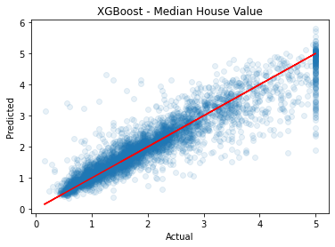

Below there is permutational variable importance for the XGBoost model. As each variable importance in this report, it was calculated using 10 permutations on 1000 observations and root-mean-squared-error loss-function. As we can see, the most important features are latitude and longitude. With any of them randomized, the loss would be around 1.5 * $100 000 higher. The third most important feature is median income, but this one and the rest of features are much less important than geographical coordinates. This finding is consistent with previous reports results for local explanations.

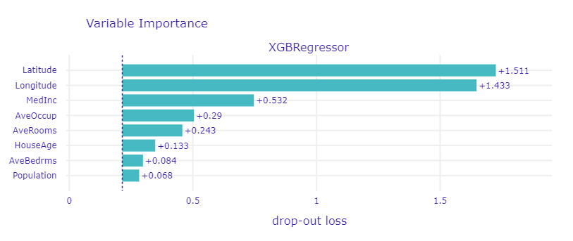

I have also trained 3 other models:

- MLP with MinMaxScaler, 3 hidden layers (64, 64, 64) and ReLU activation
- Random Forest Regressor with default scikit-learn hyperparameters
- Linear Regression with MinMaxScaler and default scikit-learn hyperparameters

MLP and Random Forest are a little worse than XGBoost but Linear Regression gives much worse predictions. Below there are validation results:

|  | **MLP** | **Random Forest** | **Linear** |
| --- | --- | --- | --- |
| **MSE** | 0.29 | 0.25 | 0.56 |
| **R^2** | 0.78 | 0.81 | 0.58 |

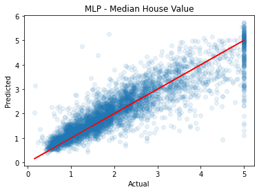

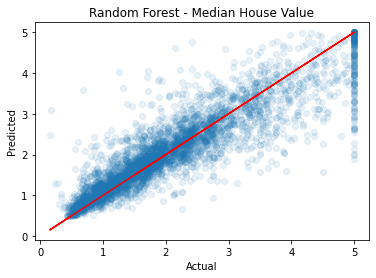

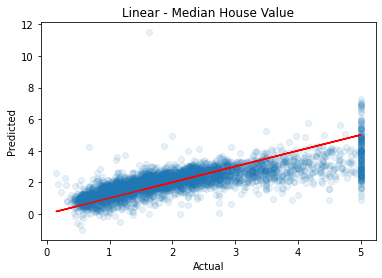

The next three figures show permutational variable importance for the models. As we can see, the most important variables for the MLP model are similar to the XGBoost ones. The geographical coordinates are also the most important features for the Linear Regression, but median income is almost as important. Different results were obtained for the Random Forest Regressor. Latitude and longitude are the 2nd and the 3rd most important features with average occupancy nearly as important as them, but the most important feature is median income. Possible hypothesis is that people with similar incomes live in similar locations.

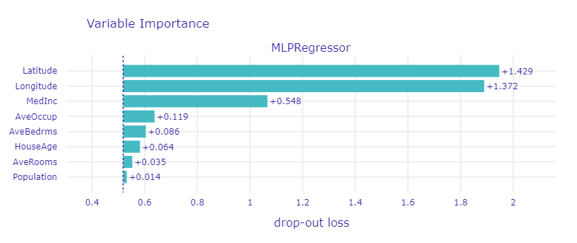

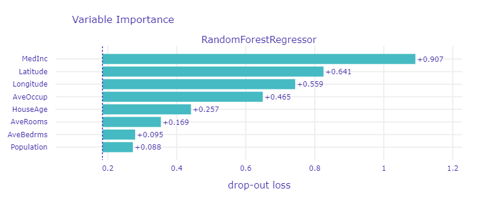

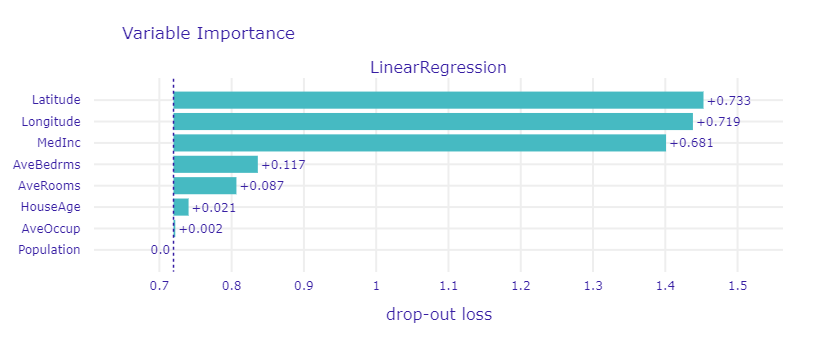

Below there is a heatmap of correlation, but it does not show significant correlation between median income and any of the coordinates.

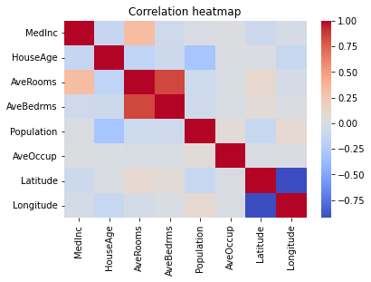

The next figure shows median income and location for each block of houses. As we can see, there are areas with lower income and other areas with higher income. It shows the posed hypothesis might be true.

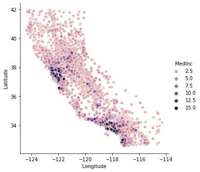

## Appendix

```python
from matplotlib import pyplot
import seaborn as sns
import dalex as dx
from xgboost import XGBRegressor

from sklearn import metrics
from sklearn.model_selection import train_test_split
from sklearn.datasets import fetch_california_housing
from sklearn.preprocessing import MinMaxScaler
from sklearn.pipeline import make_pipeline
from sklearn.neural_network import MLPRegressor
from sklearn.ensemble import RandomForestRegressor
from sklearn.linear_model import LinearRegression

def evaluate(testY, predY, model_name):
    pyplot.plot(testY, testY, 'r')
    pyplot.scatter(testY, predY, alpha=0.1)
    pyplot.title(model_name + ' - Median House Value');
    pyplot.xlabel('Actual')
    pyplot.ylabel('Predicted')
    pyplot.show()

    print()
    print("MSE:", metrics.mean_squared_error(testY, predY))
    print("MAE:", metrics.mean_absolute_error(testY, predY))
    print("R2:", metrics.r2_score(testY, predY))

def plot_importance(model, X_train, y_train):
    explainer = dx.Explainer(model, X_train, y_train)
    explainer.model_parts().plot()
```

### Data loading

```python
X, y = fetch_california_housing(return_X_y=True, as_frame=True)
X_train, X_test, y_train, y_test = train_test_split(X, y, test_size=0.2, random_state=42)
```

```python
print('features:', X_train.shape[1])
print('X_train length:', X_train.shape[0])
print('X_test length:', X_test.shape[0])
```

[output not shown]

### Training

#### XGBoost Regressor

```python
model_XGB = XGBRegressor(objective='reg:squarederror', n_estimators=1000, max_depth=5)
model_XGB.fit(X_train, y_train)
y_pred = model_XGB.predict(X_test)
evaluate(y_test, y_pred, "XGBoost")
```

#### Multi Layer Perceptron

```python
model_MLP = make_pipeline(MinMaxScaler(), MLPRegressor((64, 64, 64), learning_rate='adaptive', max_iter=1000))
model_MLP.fit(X_train, y_train)
y_pred = model_MLP.predict(X_test)
evaluate(y_test, y_pred, "MLP")
```

#### Random Forest Regressor

```python
model_RF = RandomForestRegressor()
model_RF.fit(X_train, y_train)
y_pred = model_RF.predict(X_test)
evaluate(y_test, y_pred, "Random Forest")
```

#### Linear Regression

```python
model_LR = make_pipeline(MinMaxScaler(), LinearRegression())
model_LR.fit(X_train, y_train)
y_pred = model_LR.predict(X_test)
evaluate(y_test, y_pred, "Linear")
```

### Variable Importance

```python
models = [model_XGB, model_MLP, model_RF, model_LR]

for model in models:
    plot_importance(model, X_train, y_train)
```

```python
sns.heatmap(X.corr(), cmap='coolwarm')
pyplot.title('Correlation heatmap')
pyplot.show()
```

```python
sns.relplot(x="Longitude", y="Latitude", hue="MedInc", data=X.sort_values("MedInc"))
```